# Mini Project 3: Visualizing and Maintaining the Green Canopy of NYC

Author

Wendy Fung-Wu

## Introduction

**New York City’s street trees** are a critical component of its urban infrastructure.They provide shade, reduce urban heat, improve air quality, absorb stormwater, and contribute to the aesthetic and social quality of dense neighborhoods. However, the benefits of this “green canopy” are not distributed evenly across the city, and many trees are aging, damaged, or dead.Identifying where trees are located—and how their condition varies across neighborhoods—is an essential step toward making informed and equitable investment decisions.

## Data Acquisition

### Task 1: Download NYC City Council District Boundaries

```r
# You’ll need sf (and optionally tidyverse for later work)
if (!requireNamespace("sf", quietly = TRUE)) install.packages("sf")
library(sf)

download_nyc_council_districts <- function(
    dir_path = "data/mp03",
    zip_url  = "https://www1.nyc.gov/assets/planning/download/zip/data-maps/open-data/nycc_20b.zip",
    simplify_tolerance = NULL  # in meters; e.g., 5 or 10 if you want to simplify
) {
  # 1. Ensure data/mp03 exists
  if (!dir.exists(dir_path)) {
    dir.create(dir_path, recursive = TRUE)
  }

  # 2. Set local file paths
  zip_file <- file.path(dir_path, "nyc_council_districts.zip")
  shp_dir  <- file.path(dir_path, "nyc_council_districts")

  # 3. Download the zip ONLY if needed
  if (!file.exists(zip_file)) {
    message("Downloading NYC City Council District shapefile zip...")
    download.file(zip_url, destfile = zip_file, mode = "wb")
  } else {
    message("Using cached zip file: ", zip_file)
  }

  # 4. Unzip ONLY if needed
  if (!dir.exists(shp_dir)) {
    message("Unzipping shapefile contents...")
    unzip(zip_file, exdir = shp_dir)
  } else {
    message("Using existing unzipped directory: ", shp_dir)
  }

  # 5. Find the .shp file inside the unzipped directory
  shp_path <- list.files(
    shp_dir,
    pattern = "\\.shp$",
    full.names = TRUE,
    recursive = TRUE
  )

  if (length(shp_path) == 0L) {
    stop("No .shp file found in ", shp_dir)
  }

  # If there are multiple, just take the first one (typically nycc.shp)
  shp_path <- shp_path[1]
  message("Reading shapefile: ", shp_path)

  nyc_cc <- sf::st_read(shp_path, quiet = TRUE)

  # 6. Transform to WGS 84 (as required)
  nyc_cc <- sf::st_transform(nyc_cc, crs = "WGS84")

  # 7. OPTIONAL: simplify the geometry if a tolerance is supplied
  if (!is.null(simplify_tolerance)) {
    message("Simplifying geometry with dTolerance = ", simplify_tolerance, " meters...")
    nyc_cc$geometry <- sf::st_simplify(
      nyc_cc$geometry,
      dTolerance = simplify_tolerance
    )
  }

  # 8. Return the transformed (and possibly simplified) sf object
  nyc_cc
}

council_districts <- download_nyc_council_districts(simplify_tolerance = NULL)
```

### Task 2: Download Tree Points

```r
library(httr2)
library(sf)
library(dplyr)

get_tree_points <- function(page_size = 50000) {
  base_url <- "https://data.cityofnewyork.us/resource/uvpi-gqnh.geojson"
  dir.create("data/mp03", recursive = TRUE, showWarnings = FALSE)
  offset <- 0
  page_num <- 1
  files <- character(0)
  repeat {
    filename <- sprintf("data/mp03/trees_page_%03d.geojson", page_num)
    if (!file.exists(filename)) {
      message("Downloading page ", page_num, " (offset = ", offset, ")")
      request(base_url) |>
        req_url_query(`$limit` = page_size, `$offset` = offset) |>
        req_headers(`User-Agent` = "Educational R Project") |>
        req_retry(max_tries = 3) |>
        req_perform(path = filename)
      Sys.sleep(0.5)
    } else {
      message("Using cached file: ", filename)
    }
    page <- st_read(filename, quiet = TRUE)
    n <- nrow(page)
    message("Got ", n, " rows")
    files <- c(files, filename)
    if (n < page_size) break
    offset <- offset + page_size
    page_num <- page_num + 1
  }
  pages <- lapply(files, function(f) st_read(f, quiet = TRUE))
  trees <- bind_rows(pages)
  trees
}

build_points_from_coords <- function(x) {
  df <- if (inherits(x, "sf")) sf::st_drop_geometry(x) else as.data.frame(x)
  if (all(c("longitude", "latitude") %in% names(df))) {
    lon_col <- "longitude"
    lat_col <- "latitude"
  } else if (all(c("x_sp", "y_sp") %in% names(df))) {
    lon_col <- "x_sp"
    lat_col <- "y_sp"
  } else {
    stop("Could not find longitude/latitude (or x_sp/y_sp) columns in trees data.")
  }
  df |>
    mutate(across(all_of(c(lon_col, lat_col)), as.numeric)) |>
    filter(is.finite(.data[[lon_col]]), is.finite(.data[[lat_col]])) |>
    filter(
      between(.data[[lon_col]], -74.30, -73.60),
      between(.data[[lat_col]], 40.45, 41.10)
    ) |>
    st_as_sf(coords = c(lon_col, lat_col), crs = 4326, remove = TRUE) |>
    st_make_valid()
}

if (!exists("TREES_CLEAN")) {
  if (file.exists("data/mp03/trees_clean.rds")) {
    message("Loading cached trees_clean.rds...")
    TREES_CLEAN <- readRDS("data/mp03/trees_clean.rds")
  } else {
    TREES <- get_tree_points()
    TREES_CLEAN <- build_points_from_coords(TREES)
    saveRDS(TREES_CLEAN, "data/mp03/trees_clean.rds")
  }
}

trees_sf <- TREES_CLEAN
```

## Data Integration and Initial Exploration

### Task 3: Plot All Tree Points

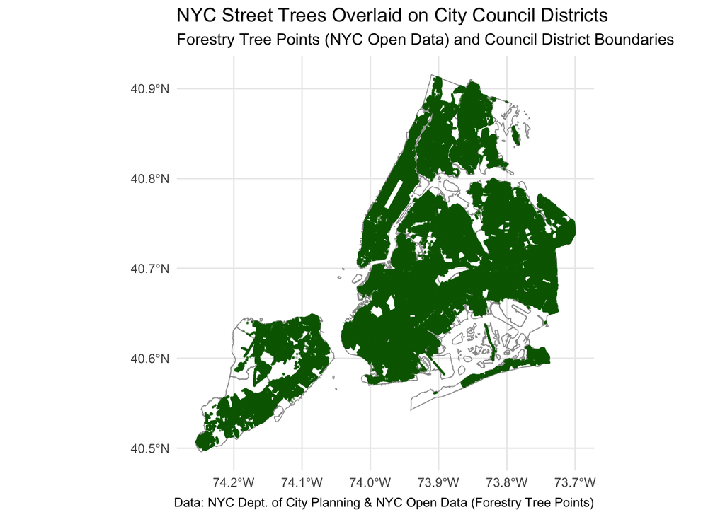

```r
library(ggplot2)
library(sf)
library(dplyr)

trees_plot <- trees_sf

ggplot() +

# Council district polygons

geom_sf(
data  = council_districts,
fill  = NA,
color = "grey60",
linewidth = 0.3
) +

# Tree points

geom_sf(
data  = trees_plot,
color = "darkgreen",
alpha = 0.25,
size  = 0.1
) +
coord_sf() +
labs(
title   = "NYC Street Trees Overlaid on City Council Districts",
subtitle = "Forestry Tree Points (NYC Open Data) and Council District Boundaries",
caption = "Data: NYC Dept. of City Planning & NYC Open Data (Forestry Tree Points)"
) +
theme_minimal()
```

### Task 4: District-Level Analysis of Tree Coverage

#### Q1: Which council district has the most trees?

```r
library(sf)
library(dplyr)
library(knitr)
library(kableExtra)
library(scales)

# Build trees_districts here if it doesn't already exist ---------------------

if (!exists("trees_districts")) {
trees_districts <- st_join(
trees_sf,
council_districts |>
dplyr::select(CounDist, Shape_Area),
join = st_within,
left = TRUE
) |>
mutate(
borough = case_when(
CounDist >=  1 & CounDist <= 10 ~ "Manhattan",
CounDist >= 11 & CounDist <= 18 ~ "Bronx",
CounDist >= 19 & CounDist <= 32 ~ "Queens",
CounDist >= 33 & CounDist <= 48 ~ "Brooklyn",
CounDist >= 49 & CounDist <= 51 ~ "Staten Island",
TRUE                             ~ NA_character_
)
)
}

# Q1: Which council district has the most trees? -----------------------------

trees_by_district <- trees_districts |>
st_drop_geometry() |>
group_by(CounDist) |>
summarize(n_trees = n(), .groups = "drop") |>
arrange(desc(n_trees))

# Save the top district for the written answer

q1_top <- trees_by_district |>
slice_head(n = 1)

# Pretty table: top 10 districts by number of trees --------------------------

trees_by_district |>
slice_head(n = 10) |>
rename(
`Council District` = CounDist,
`Number of Trees`  = n_trees
) |>
mutate(`Number of Trees` = comma(`Number of Trees`)) |>
kable(
format  = "html",
align   = c("c", "r"),
caption = "Top 10 NYC Council Districts by Number of Street Trees"
) |>
kable_styling(
bootstrap_options = c("striped", "hover", "condensed"),
full_width        = FALSE,
position          = "center"
)
```

Top 10 NYC Council Districts by Number of Street Trees

| Council District | Number of Trees |
| --- | --- |
| 51 | 51,236 |
| 19 | 34,389 |
| 50 | 33,035 |
| 23 | 30,712 |
| 31 | 23,152 |
| 49 | 21,047 |
| 27 | 20,115 |
| 32 | 19,508 |
| 24 | 18,993 |
| 30 | 18,551 |

**Answer (Q1):** Council District **51** has the most trees, with  
**51,236** trees.

#### Q2: Which council district has the highest density of trees?

```r
library(sf)
library(dplyr)
library(knitr)
library(kableExtra)
library(scales)

# Ensure trees_districts exists (same logic as Q1) ---------------------------

if (!exists("trees_districts")) {
trees_districts <- st_join(
trees_sf,
council_districts |>
dplyr::select(CounDist, Shape_Area),
join = st_within,
left = TRUE
) |>
mutate(
borough = case_when(
CounDist >=  1 & CounDist <= 10 ~ "Manhattan",
CounDist >= 11 & CounDist <= 18 ~ "Bronx",
CounDist >= 19 & CounDist <= 32 ~ "Queens",
CounDist >= 33 & CounDist <= 48 ~ "Brooklyn",
CounDist >= 49 & CounDist <= 51 ~ "Staten Island",
TRUE                             ~ NA_character_
)
)
}

# Trees per district (from Q1) -----------------------------------------------

trees_by_district <- trees_districts |>
st_drop_geometry() |>
group_by(CounDist) |>
summarize(n_trees = n(), .groups = "drop")

# Bring in Shape_Area from council_districts ---------------------------------

district_area <- council_districts |>
st_drop_geometry() |>
select(CounDist, Shape_Area)

# Compute density: trees per km^2 --------------------------------------------

density_by_district <- trees_by_district |>
left_join(district_area, by = "CounDist") |>
mutate(
area_km2      = Shape_Area / 1e6,       # assuming Shape_Area is in m^2
trees_per_km2 = n_trees / area_km2
) |>
arrange(desc(trees_per_km2))

# Top district for inline answer

q2_top <- density_by_district |>
slice_head(n = 1)

# Pretty table: Top 10 by tree density, including Shape_Area -----------------

density_by_district |>
slice_head(n = 10) |>
rename(
`Council District` = CounDist,
`Number of Trees`  = n_trees,
`Shape Area (m²)`  = Shape_Area,
`Area (km²)`       = area_km2,
`Trees per km²`    = trees_per_km2
) |>
mutate(
`Number of Trees` = comma(`Number of Trees`),
`Shape Area (m²)` = comma(`Shape Area (m²)`),
`Area (km²)`      = round(`Area (km²)`, 2),
`Trees per km²`   = round(`Trees per km²`, 1)
) |>
kable(
format  = "html",
align   = c("c", "r", "r", "r", "r"),
caption = "Top 10 NYC Council Districts by Tree Density"
) |>
kable_styling(
bootstrap_options = c("striped", "hover", "condensed"),
full_width        = FALSE,
position          = "center"
)
```

Top 10 NYC Council Districts by Tree Density

| Council District | Number of Trees | Shape Area (m²) | Area (km²) | Trees per km² |
| --- | --- | --- | --- | --- |
| 9 | 8,213 | 57,262,987 | 57.26 | 143.4 |
| 5 | 4,982 | 37,216,445 | 37.22 | 133.9 |
| 35 | 10,525 | 81,510,739 | 81.51 | 129.1 |
| 7 | 6,572 | 51,409,605 | 51.41 | 127.8 |
| 44 | 11,659 | 92,757,492 | 92.76 | 125.7 |
| 25 | 7,851 | 63,560,956 | 63.56 | 123.5 |
| 4 | 8,522 | 70,494,165 | 70.49 | 120.9 |
| 14 | 6,240 | 51,648,156 | 51.65 | 120.8 |
| 39 | 13,860 | 116,496,928 | 116.50 | 119.0 |
| 36 | 9,023 | 76,221,712 | 76.22 | 118.4 |

**Answer (Q2):** Council District **9** has the highest tree density,  
with about **143.4** trees per square kilometer.

#### Q3: Which district has the highest fraction of dead trees?

```r
library(sf)
library(dplyr)
library(knitr)
library(kableExtra)
library(scales)

# Ensure trees_districts exists (same pattern as Q1 & Q2) --------------------

if (!exists("trees_districts")) {
trees_districts <- st_join(
trees_sf,
council_districts |>
dplyr::select(CounDist, Shape_Area),
join = st_within,
left = TRUE
) |>
mutate(
borough = case_when(
CounDist >=  1 & CounDist <= 10 ~ "Manhattan",
CounDist >= 11 & CounDist <= 18 ~ "Bronx",
CounDist >= 19 & CounDist <= 32 ~ "Queens",
CounDist >= 33 & CounDist <= 48 ~ "Brooklyn",
CounDist >= 49 & CounDist <= 51 ~ "Staten Island",
TRUE                             ~ NA_character_
)
)
}

# Compute fraction of dead trees per district --------------------------------

# For the NYC Street Tree Census (uvpi-gqnh), `status == "Dead"` marks dead trees.

dead_fraction <- trees_districts |>
st_drop_geometry() |>
filter(!is.na(CounDist)) |>
mutate(is_dead = status == "Dead") |>
group_by(CounDist) |>
summarize(
n_trees   = n(),
n_dead    = sum(is_dead, na.rm = TRUE),
frac_dead = n_dead / n_trees,
.groups   = "drop"
) |>
arrange(desc(frac_dead))

# Top district for inline answer

q3_top <- dead_fraction |>
slice_head(n = 1)

# Pretty table: Top 10 districts by fraction of dead trees -------------------

dead_fraction |>
slice_head(n = 10) |>
rename(
`Council District`    = CounDist,
`Number of Trees`     = n_trees,
`Number of Dead Trees`= n_dead,
`Fraction Dead`       = frac_dead
) |>
mutate(
`Percent Dead` = percent(`Fraction Dead`, accuracy = 0.1)
) |>
kable(
format  = "html",
align   = c("c", "r", "r", "r", "r"),
caption = "Top 10 NYC Council Districts by Fraction of Dead Street Trees"
) |>
kable_styling(
bootstrap_options = c("striped", "hover", "condensed"),
full_width        = FALSE,
position          = "center"
)
```

Top 10 NYC Council Districts by Fraction of Dead Street Trees

| Council District | Number of Trees | Number of Dead Trees | Fraction Dead | Percent Dead |
| --- | --- | --- | --- | --- |
| 16 | 6518 | 361 | 0.0553851 | 5.5% |
| 8 | 7306 | 306 | 0.0418834 | 4.2% |
| 17 | 11851 | 482 | 0.0406717 | 4.1% |
| 15 | 8044 | 321 | 0.0399055 | 4.0% |
| 14 | 6240 | 224 | 0.0358974 | 3.6% |
| 10 | 6501 | 226 | 0.0347639 | 3.5% |
| 3 | 8631 | 283 | 0.0327888 | 3.3% |
| 34 | 10812 | 349 | 0.0322789 | 3.2% |
| 1 | 5694 | 180 | 0.0316122 | 3.2% |
| 7 | 6572 | 207 | 0.0314973 | 3.1% |

**Answer (Q3):** Council District **16** has the highest fraction of dead trees,  
with about **5.5%** of its street trees classified as dead.

#### Q4: What is the most common tree species in Manhattan?

```r
library(sf)
library(dplyr)
library(knitr)
library(kableExtra)
library(scales)

# Ensure trees_districts exists (same pattern as earlier questions) ----------

if (!exists("trees_districts")) {
trees_districts <- st_join(
trees_sf,
council_districts |>
dplyr::select(CounDist, Shape_Area),
join = st_within,
left = TRUE
) |>
mutate(
borough = case_when(
CounDist >=  1 & CounDist <= 10 ~ "Manhattan",
CounDist >= 11 & CounDist <= 18 ~ "Bronx",
CounDist >= 19 & CounDist <= 32 ~ "Queens",
CounDist >= 33 & CounDist <= 48 ~ "Brooklyn",
CounDist >= 49 & CounDist <= 51 ~ "Staten Island",
TRUE                             ~ NA_character_
)
)
}

# Filter to Manhattan and tally species (spc_common) -------------------------

manhattan_species <- trees_districts |>
st_drop_geometry() |>
filter(borough == "Manhattan") |>
filter(!is.na(spc_common)) |>
count(spc_common, sort = TRUE, name = "n_trees")

# Top species for inline answer

q4_top <- manhattan_species |>
slice_head(n = 1)

# Pretty table: Top 10 most common species in Manhattan ----------------------

manhattan_species |>
slice_head(n = 10) |>
rename(
`Common Species Name` = spc_common,
`Number of Trees`     = n_trees
) |>
mutate(`Number of Trees` = comma(`Number of Trees`)) |>
kable(
format  = "html",
align   = c("l", "r"),
caption = "Top 10 Most Common Street Tree Species in Manhattan"
) |>
kable_styling(
bootstrap_options = c("striped", "hover", "condensed"),
full_width        = FALSE,
position          = "center"
)
```

Top 10 Most Common Street Tree Species in Manhattan

| Common Species Name | Number of Trees |
| --- | --- |
| honeylocust | 13,900 |
| Callery pear | 7,537 |
| ginkgo | 6,011 |
| pin oak | 4,893 |
| Sophora | 4,628 |
| London planetree | 4,497 |
| Japanese zelkova | 3,920 |
| littleleaf linden | 3,570 |
| American elm | 1,830 |
| American linden | 1,779 |

**Answer (Q4):** In Manhattan, the most common street tree species is  
**honeylocust**, with **13,900** recorded trees.

#### Q5: What is the species of the tree closest to Baruch’s campus?

```r
library(sf)
library(dplyr)
library(knitr)
library(kableExtra)
library(scales)
library(ggplot2)

# 1. Approximate coordinates of Baruch College (23rd St & Lexington Ave) -----

baruch_lat <- 40.740173
baruch_lon <- -73.98337

# Create an sf point for Baruch in WGS84

baruch_point <- st_sfc(
st_point(c(baruch_lon, baruch_lat)),  # c(lon, lat)
crs = 4326
)

# 2. Make sure trees_sf has a CRS and matches Baruch's CRS -------------------

if (is.na(st_crs(trees_sf))) {
st_crs(trees_sf) <- 4326
}

# 3. Compute geodesic distance from each tree to Baruch (in meters) ---------

dist_vec <- st_distance(trees_sf, baruch_point)
dist_m   <- as.numeric(dist_vec)  # drop units for easier use

# 4. Find the nearest tree ---------------------------------------------------

q5_nearest <- trees_sf |>
mutate(distance_m = dist_m) |>
slice_min(distance_m, n = 1)

# 5. Pretty table with key info ---------------------------------------------

q5_nearest |>
st_drop_geometry() |>
transmute(
`Common Species Name` = spc_common,
`Latin Name`          = spc_latin,
`Tree Status`         = status,
`Distance (meters)`   = round(distance_m, 1),
`Distance (miles)`    = round(distance_m / 1609.34, 3)
) |>
kable(
format  = "html",
align   = c("l", "l", "c", "r", "r"),
caption = "Nearest Street Tree to Baruch College (by straight-line distance)"
) |>
kable_styling(
bootstrap_options = c("striped", "hover", "condensed"),
full_width        = FALSE,
position          = "center"
)
```

Nearest Street Tree to Baruch College (by straight-line distance)

| Common Species Name | Latin Name | Tree Status | Distance (meters) | Distance (miles) |
| --- | --- | --- | --- | --- |
| Callery pear | Pyrus calleryana | Alive | 36.5 | 0.023 |

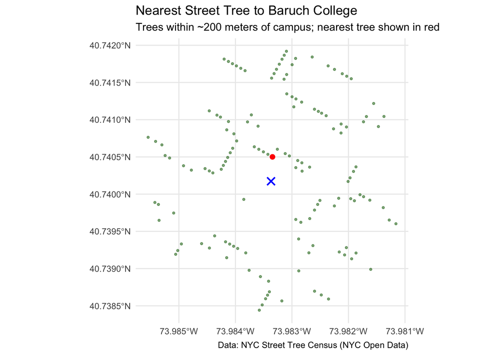

```r
# 6. Find trees within ~200 meters of Baruch for the map --------------------

near_idx <- st_is_within_distance(
trees_sf,
baruch_point,
dist   = 200,
sparse = FALSE      # <-- return a logical matrix so [,1] works
)

trees_near_baruch <- trees_sf[near_idx[, 1], ]

# 7. Build bounding box for zoomed-in map -----------------------------------

bbox <- st_bbox(trees_near_baruch)

# 8. Create an sf object for the Baruch point for plotting -------------------

baruch_sf <- st_sf(
label    = "Baruch College",
geometry = baruch_point
)

# 9. Plot: zoomed-in map around Baruch, nearest tree highlighted ------------

ggplot() +

# Optional: faint council district boundaries in the background

geom_sf(
data  = council_districts,
fill  = NA,
color = "grey85",
linewidth = 0.3
) +

# Trees near Baruch

geom_sf(
data  = trees_near_baruch,
color = "darkgreen",
alpha = 0.5,
size  = 0.8
) +

# Nearest tree: bright red

geom_sf(
data  = q5_nearest,
color = "red",
size  = 2
) +

# Baruch point: blue X

geom_sf(
data  = baruch_sf,
color = "blue",
shape = 4,
size  = 3,
stroke = 1.1
) +
coord_sf(
xlim = c(bbox["xmin"], bbox["xmax"]),
ylim = c(bbox["ymin"], bbox["ymax"])
) +
labs(
title    = "Nearest Street Tree to Baruch College",
subtitle = "Trees within ~200 meters of campus; nearest tree shown in red",
caption  = "Data: NYC Street Tree Census (NYC Open Data)"
) +
theme_minimal()
```

**Answer (Q5):** The street tree closest to Baruch’s campus is a  
**Callery pear** (Latin name *Pyrus calleryana*),  
located about **36.5** meters  
(≈ **0.023** miles) from campus.

## Government Project Design

### Task 5: NYC Parks Proposal

```r
# Task 5 setup for District 38 (Brooklyn)

library(sf)
library(dplyr)
library(ggplot2)
library(kableExtra)
library(scales)

# Focus district: where you live

focus_district <- 38

# Make sure trees_districts exists (reuse logic from Task 4 if needed)

if (!exists("trees_districts")) {
trees_districts <- st_join(
trees_sf,
council_districts |>
dplyr::select(CounDist, Shape_Area),
join = st_within,
left = TRUE
) |>
mutate(
borough = case_when(
CounDist >=  1 & CounDist <= 10 ~ "Manhattan",
CounDist >= 11 & CounDist <= 18 ~ "Bronx",
CounDist >= 19 & CounDist <= 32 ~ "Queens",
CounDist >= 33 & CounDist <= 48 ~ "Brooklyn",
CounDist >= 49 & CounDist <= 51 ~ "Staten Island",
TRUE                             ~ NA_character_
)
)
}

# Trees and geometry for District 38 -----------------------------------------

trees_focus <- trees_districts |>
filter(CounDist == focus_district)

focus_borough <- trees_focus$borough[!is.na(trees_focus$borough)][1]

district_geom <- council_districts |>
filter(CounDist == focus_district)

# Summary of dead trees in District 38 ---------------------------------------

dead_stats <- trees_focus |>
st_drop_geometry() |>
mutate(is_dead = status == "Dead") |>
summarize(
n_trees   = n(),
n_dead    = sum(is_dead, na.rm = TRUE),
frac_dead = n_dead / n_trees
)

# Dead-tree stats for ALL districts ------------------------------------------

dead_fraction <- trees_districts |>
st_drop_geometry() |>
filter(!is.na(CounDist)) |>
mutate(is_dead = status == "Dead") |>
group_by(CounDist, borough) |>
summarize(
n_trees   = n(),
n_dead    = sum(is_dead, na.rm = TRUE),
frac_dead = n_dead / n_trees,
.groups   = "drop"
)

# Row for District 38

focus_row <- dead_fraction |>
filter(CounDist == focus_district)

# Top 3 other districts by dead fraction

others <- dead_fraction |>
filter(CounDist != focus_district) |>
arrange(desc(frac_dead)) |>
slice_head(n = 3)

compare_districts <- bind_rows(focus_row, others)

# Dead trees only in District 38 (for the map)

dead_trees_focus <- trees_focus |>
filter(status == "Dead")
```

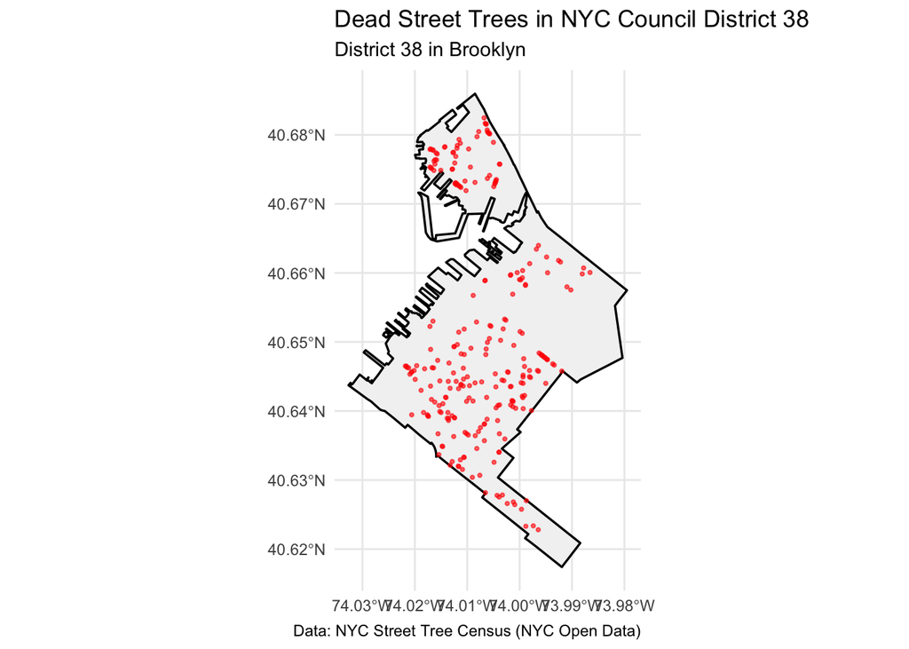

```r
# Map of dead trees in Council District 38

# Bounding box from the district polygon

bbox_38 <- st_bbox(district_geom)

ggplot() +
geom_sf(
data  = district_geom,
fill  = "grey95",
color = "black",
linewidth = 0.6
) +
geom_sf(
data  = dead_trees_focus,
color = "red",
alpha = 0.6,
size  = 0.7
) +
coord_sf(
xlim = c(bbox_38["xmin"], bbox_38["xmax"]),
ylim = c(bbox_38["ymin"], bbox_38["ymax"])
) +
labs(
title    = "Dead Street Trees in NYC Council District 38",
subtitle = paste0("District ", focus_district, " in ", focus_borough),
caption  = "Data: NYC Street Tree Census (NYC Open Data)"
) +
theme_minimal()
```

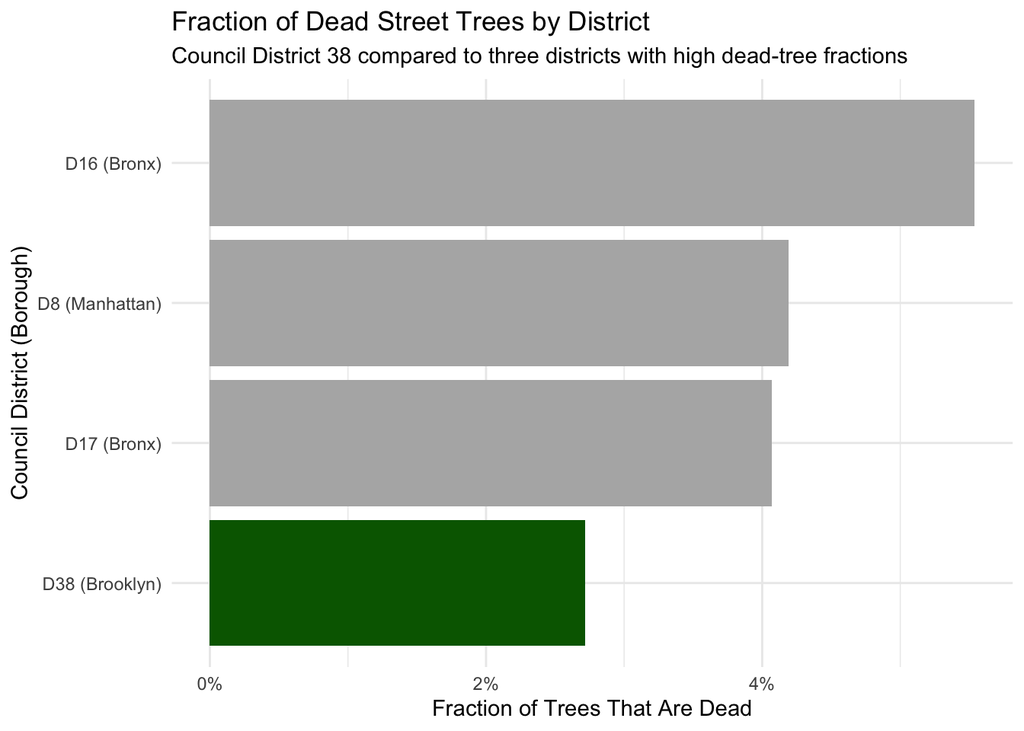

```r
# Bar chart: dead-tree fraction in District 38 vs 3 other districts

compare_plot_data <- compare_districts |>
mutate(
district_label = paste0("D", CounDist, " (", borough, ")"),
is_focus       = CounDist == focus_district
)

ggplot(compare_plot_data, aes(
x = reorder(district_label, frac_dead),
y = frac_dead,
fill = is_focus
)) +
geom_col() +
coord_flip() +
scale_y_continuous(labels = scales::percent) +
scale_fill_manual(
values = c("FALSE" = "grey70", "TRUE" = "darkgreen"),
guide  = "none"
) +
labs(
title = "Fraction of Dead Street Trees by District",
subtitle = paste0(
"Council District ", focus_district,
" compared to three districts with high dead-tree fractions"
),
x = "Council District (Borough)",
y = "Fraction of Trees That Are Dead"
) +
theme_minimal()
```

```r
# Table: Dead-tree burden in District 38 vs comparison districts

compare_plot_data |>
arrange(desc(is_focus), desc(frac_dead)) |>
transmute(
`Council District` = CounDist,
Borough            = borough,
`Number of Trees`  = n_trees,
`Dead Trees`       = n_dead,
`Percent Dead`     = percent(frac_dead, accuracy = 0.1),
`Focus District?`  = if_else(is_focus, "Yes", "No")
) |>
kable(
format  = "html",
align   = "c",
caption = "Dead Tree Burden in District 38 vs Three Comparison Districts"
) |>
kable_styling(
bootstrap_options = c("striped", "hover", "condensed"),
full_width        = FALSE,
position          = "center"
)
```

Dead Tree Burden in District 38 vs Three Comparison Districts

| Council District | Borough | Number of Trees | Dead Trees | Percent Dead | Focus District? |
| --- | --- | --- | --- | --- | --- |
| 38 | Brooklyn | 9566 | 260 | 2.7% | Yes |
| 16 | Bronx | 6518 | 361 | 5.5% | No |
| 8 | Manhattan | 7306 | 306 | 4.2% | No |
| 17 | Bronx | 11851 | 482 | 4.1% | No |

#### Proposed Project: Replacing Dead Street Trees in Council District 38 (Brooklyn)

This proposal recommends a targeted **Dead Street Tree Removal and Replacement Program** in  
**New York City Council District 38**, located in Brooklyn.  
The aim of this initiative is to reduce public safety risks, restore tree canopy coverage, and enhance  
streetscape quality in a district that combines dense residential blocks, commercial corridors,  
and heavily used pedestrian routes.

#### Background and Motivation

According to the NYC Street Tree Census, Council District 38 currently contains approximately  
**9,566** recorded street trees. Of these, an estimated  
**260** trees—approximately  
**2.7%** of the inventory—are classified as *dead*.

Dead street trees present several concerns:

- Elevated risk of limb or trunk failure, particularly during storms and high-wind events;
- Reduced shade and cooling, especially on blocks with substantial pedestrian activity;
- Deterioration of the visual quality of residential streets and commercial frontages.

The spatial analysis of the tree census data indicates that dead trees in District 38  
are not uniformly distributed. Instead, they cluster along specific corridors and blocks within the district.  
This pattern supports a targeted intervention strategy that can be operationally efficient and highly visible to residents.

#### Proposed Scope of Work

The proposed program would include the following components:

- **Removal of dead street trees**
  - Removal of approximately **260** dead street trees within Council District 38.
  - Prioritization of locations near schools, playgrounds, senior centers, transit stops, and major pedestrian corridors.
- **Replacement plantings**
  - Replanting at or near removal sites using resilient, climate-adapted species that support long-term canopy goals.
  - Coordination with existing NYC Parks planting standards and species guidelines.
- **Community coordination and stewardship**
  - Engagement with community boards, local schools, and neighborhood organizations to communicate planned removals and plantings.
  - Encouragement of local stewardship (e.g., watering and care for newly planted trees), where appropriate.

#### Anticipated Benefits

Implementation of the Dead Street Tree Removal and Replacement Program in Council District 38 is expected to:

- **Improve public safety** by addressing structurally compromised trees in a district with high pedestrian volumes;
- **Restore and stabilize the urban forest** by replacing dead trees with healthy, well-selected species;
- **Enhance neighborhood aesthetics and comfort**, particularly along key residential and commercial corridors;
- **Promote equity in urban forestry investments** by directing resources to a district with both a substantial proportion of dead trees and intensive daily use by residents and businesses.

Overall, this initiative would represent a focused, data-driven investment in the resilience, safety, and livability of Council District 38 and its communities in Brooklyn.